# Интернет-магазин «В один клик» продаёт разные товары. Отчёт магазина за прошлый период показал, что активность покупателей начала снижаться. Привлекать новых клиентов уже не так эффективно. Возможный 

### 6.3 Пайплайн для подбора гиперпараметров и масштабирования

```python
randomized_search = RandomizedSearchCV(
    pipe_final,
    param_grid,
    cv=5,
    scoring='roc_auc',
    random_state=RANDOM_STATE,
    n_jobs=-1
)

randomized_search.fit(X_train, y_train)
```

```
RandomizedSearchCV(cv=5,
                   estimator=Pipeline(steps=[('preprocessor',
                                              ColumnTransformer(remainder='passthrough',
                                                                transformers=[('num',
                                                                               Pipeline(steps=[('scaler',
                                                                                                StandardScaler())]),
                                                                               ['маркет_актив_6_мес',
                                                                                'маркет_актив_тек_мес',
                                                                                'длительность',
                                                                                'акционные_покупки',
                                                                                'средний_просмотр_категорий_за_визит',
                                                                                'неоплаченные_продукты_штук_квартал',
                                                                                'ошибка_сервиса',
                                                                                'ст...
                                        {'models': [KNeighborsClassifier(n_jobs=-1)],
                                         'models__n_neighbors': range(2, 5),
                                         'preprocessor__num': [StandardScaler(),
                                                               MinMaxScaler(),
                                                               'passthrough']},
                                        {'models': [LogisticRegression(penalty='l1',
                                                                       random_state=42,
                                                                       solver='liblinear')],
                                         'models__C': range(1, 5),
                                         'preprocessor__num': [StandardScaler(),
                                                               MinMaxScaler(),
                                                               'passthrough']}],
                   random_state=42, scoring='roc_auc')
```

### 6.4 Выявление лучшей модели

На данном этапе мы определяем лучшие параметры модели и узнаем непосредственно успех модели

```python
print('Лучшая модель и её параметры:\n\n', randomized_search.best_estimator_)
print ('Метрика лучшей модели на тренировочной выборке:', randomized_search.best_score_)
```

```
Лучшая модель и её параметры:

 Pipeline(steps=[('preprocessor',
                 ColumnTransformer(remainder='passthrough',
                                   transformers=[('num', MinMaxScaler(),
                                                  ['маркет_актив_6_мес',
                                                   'маркет_актив_тек_мес',
                                                   'длительность',
                                                   'акционные_покупки',
                                                   'средний_просмотр_категорий_за_визит',
                                                   'неоплаченные_продукты_штук_квартал',
                                                   'ошибка_сервиса',
                                                   'страниц_за_визит',
                                                   'earning1', 'earning2',
                                                   'earning3', 'time2',
                                                   'time3']),
                                                 ('cat',
                                                  Pipeline(steps=[('ohe',
                                                                   OneHotEncoder(drop='first',
                                                                                 sparse_output=False))]),
                                                  ['тип_сервиса',
                                                   'разрешить_сообщать',
                                                   'популярная_категория',
                                                   'period1', 'period2',
                                                   'period3'])])),
                ('models',
                 SVC(C=2, kernel='linear', probability=True, random_state=42))])
Метрика лучшей модели на тренировочной выборке: 0.8933876727967636
```

```python
randomized_search.best_params_
```

```
{'preprocessor__num': MinMaxScaler(),
 'models__C': 2,
 'models': SVC(C=2, kernel='linear', probability=True, random_state=42)}
```

Таким образом лучшей моделью стал SVC с C=2, линейным ядром, OneHotEncoder'ом и MinMaxScaler'ом

Мною была выбрана метрика ROC_AUC так как у нас задача бинарной классификации

```python
y_test_pred = randomized_search.predict(X_test)
roc_auc_test = roc_auc_score(y_test, y_test_pred).mean()
print(f'Метрика ROC-AUC на тестовой выборке: {roc_auc_test}')
```

```
Метрика ROC-AUC на тестовой выборке: 0.8990413784734862
```

Таким образом, в данном шаге мы построили общий целостный пайплайн для нашего бизнес-кейса. В первую очередь нужно было преобразовать столбец, который мы предсказываем, в бинарный вид (именно численный), так как модели МО кажется не работают со стороковыми значениями целевого признака. Дальнейшим шагом было разбиение столбцов на категориальные и численные, а так же создание тренировочных и тестовых выборок. Далее мы создали пайплайн для преобразования столбцов: в случае с численными значениями, мы применяли масштабирование, а для категориальных признаков - кодирование. Далее был создан пайплайн с некоторым множеством моделей и уникальным набором гиперпараметров в зависимости от типа модели. Следующим шагом стал рандомизированный подбор этих самых моделей со случайным набором гиперпараметров заданных нами, при этом была учтена метрика roc_auc. В итоге, мы получили финальную лучшую модель и оценки её качества на двух выборках. Для улучшения качества модели у нас есть много способов, начиная от создания еще большего множества моделей с еще большим набором гиперпараметров и настроек кодировщиков/масштабирований с их внутренними настройками, и аж до изменения рандомного подбора моделей и параметров на полный перебор.

## 7 Шаг. Анализ важности признаков

### 7.1 Оценим важность признаков для лучшей модели и построим график важности SHAP.

```python
categorical_transformer = randomized_search.best_estimator_['preprocessor'].transformers[1][1][0]
numerical_transformer = randomized_search.best_estimator_['preprocessor'].transformers[0][1]
df_ohe = pd.DataFrame(categorical_transformer.fit_transform(X_train[categorical_columns]), columns = categorical_transformer.get_feature_names_out())
df_num = pd.DataFrame(numerical_transformer.fit_transform(X_train[numerical_columns]), columns = numerical_columns)
X = pd.concat([df_num, df_ohe], axis=1)

explainer = shap.LinearExplainer(randomized_search.best_estimator_['models'], X)
shap_values = explainer(X)
```

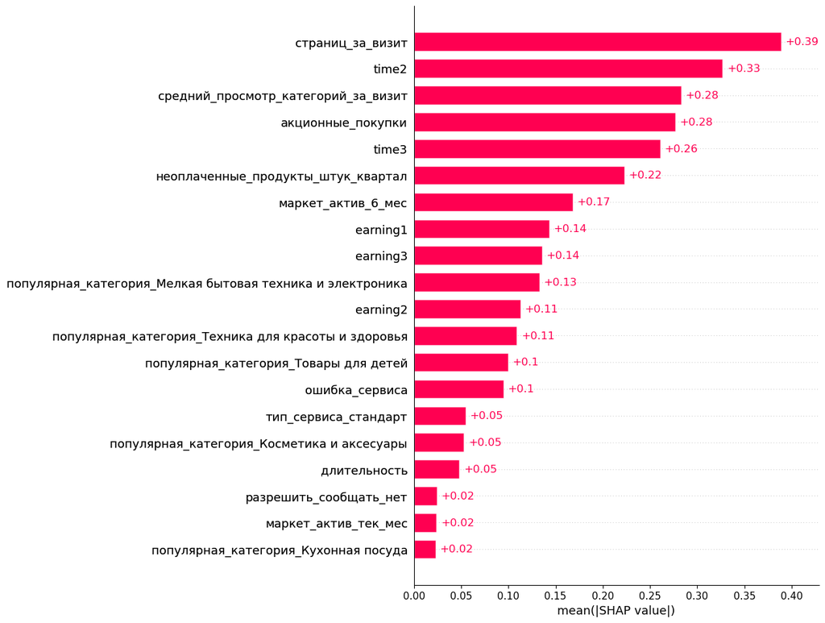

```python
shap.plots.bar(shap_values, max_display=None)
```

### 7.2 Выводы о значимости признаков:

Таким образом мы имеем целых три бесполезных признака: 1) разрешить_сообщать_нет, 2) маркет_актив_тек_мес, 3) популярная_категория_Кухонная посуда. В топ 5 полезных признаков: 1) страниц_за_визит, 2) time2, 3) средний_просмотр_категорий_за_визит, 4) акционные_покупки, 5) time3. Итого получаем, что не стоит учитывать в моделировании то, разрешил ли уведомления клиент, количество маркетинговых коммуникаций в текущем месяце и интересовала ли его кухонная посуда, и наоборот улучшать рекомендательную систему, которая будет часто выдавать наиболее актуальные категории товаров для пользователей, а так же чаще предлагать что-то акционное.

## 8 Шаг. Сегментация покупателей

### 8.1 Выполним сегментацию покупателей по результатам моделирования и данных о прибыльности покупателей

Допустим, выберем самую первую группу, а именно группа клиентов с максимальной долей покупок по акции и высокой вероятностью снижения покупательской активности

```python
result = pd.DataFrame(pd.concat([pd.Series(randomized_search.best_estimator_.predict_proba(X_test)[:,1]), pd.Series(X_test.index)], axis = 1))
result.columns = ['вероятность_снижения', 'id']
```

Здесь мы выбираем получаем процентные предсказания по отношению пользователей к категориям

```python
result.head(5)
```

|  | вероятность_снижения | id |
| --- | --- | --- |
| 0 | 0.016951 | 216161 |
| 1 | 0.987588 | 215654 |
| 2 | 0.105269 | 216307 |
| 3 | 0.832612 | 215501 |
| 4 | 0.608756 | 215934 |

```python
result = result.set_index('id')
```

```python
result.head(5)
```

| id | вероятность_снижения |
| --- | --- |
| 216161 | 0.016951 |
| 215654 | 0.987588 |
| 216307 | 0.105269 |
| 215501 | 0.832612 |
| 215934 | 0.608756 |

Мержим непосредственно с датафреймом на котором делали предсказания по id, теперь убедимся что все ок и перейдем к анализу с помощью исследовательского анализа данных

```python
one_df = X_test.merge(result, left_index=True, right_index=True, how='left')
one_df
```

| id | тип_сервиса | разрешить_сообщать | маркет_актив_6_мес | маркет_актив_тек_мес | длительность | акционные_покупки | популярная_категория | средний_просмотр_категорий_за_визит | неоплаченные_продукты_штук_квартал | ошибка_сервиса | страниц_за_визит | period1 | earning1 | period2 | earning2 | period3 | earning3 | time2 | time3 | вероятность_снижения |
| --- | --- | --- | --- | --- | --- | --- | --- | --- | --- | --- | --- | --- | --- | --- | --- | --- | --- | --- | --- | --- |
| 216161 | стандарт | да | 4.1 | 4 | 606 | 0.15 | Техника для красоты и здоровья | 6 | 1 | 4 | 12 | препредыдущий_месяц | 4912.0 | предыдущий_месяц | 3973.0 | текущий_месяц | 3289.2 | 16 | 17 | 0.016951 |
| 215654 | премиум | нет | 1.4 | 4 | 684 | 0.94 | Товары для детей | 3 | 6 | 1 | 6 | препредыдущий_месяц | 4656.0 | предыдущий_месяц | 3548.0 | текущий_месяц | 4170.7 | 11 | 9 | 0.987588 |
| 216307 | премиум | да | 3.3 | 4 | 488 | 0.13 | Домашний текстиль | 4 | 2 | 8 | 10 | препредыдущий_месяц | 4565.0 | предыдущий_месяц | 5444.0 | текущий_месяц | 6335.8 | 20 | 11 | 0.105269 |
| 215501 | премиум | да | 3.5 | 3 | 1057 | 0.35 | Домашний текстиль | 4 | 3 | 5 | 6 | препредыдущий_месяц | 4993.0 | предыдущий_месяц | 6604.0 | текущий_месяц | 6758.7 | 9 | 9 | 0.832612 |
| 215934 | стандарт | нет | 5.5 | 4 | 147 | 0.99 | Мелкая бытовая техника и электроника | 1 | 2 | 3 | 7 | препредыдущий_месяц | 4451.0 | предыдущий_месяц | 5090.0 | текущий_месяц | 5773.8 | 15 | 18 | 0.608756 |
| ... | ... | ... | ... | ... | ... | ... | ... | ... | ... | ... | ... | ... | ... | ... | ... | ... | ... | ... | ... | ... |
| 215429 | премиум | нет | 0.9 | 4 | 690 | 0.24 | Домашний текстиль | 2 | 5 | 7 | 4 | препредыдущий_месяц | 4488.0 | предыдущий_месяц | 3662.0 | текущий_месяц | 4158.6 | 11 | 10 | 0.954797 |
| 216233 | премиум | да | 3.9 | 4 | 1048 | 0.21 | Техника для красоты и здоровья | 3 | 0 | 6 | 14 | препредыдущий_месяц | 4553.0 | предыдущий_месяц | 4325.0 | текущий_месяц | 4257.4 | 15 | 17 | 0.054391 |
| 215716 | стандарт | да | 2.4 | 4 | 952 | 0.30 | Техника для красоты и здоровья | 3 | 5 | 2 | 3 | препредыдущий_месяц | 4165.0 | предыдущий_месяц | 3067.0 | текущий_месяц | 3343.9 | 13 | 14 | 0.854029 |
| 216141 | стандарт | нет | 4.0 | 4 | 748 | 0.28 | Косметика и аксесуары | 4 | 0 | 4 | 9 | препредыдущий_месяц | 4885.0 | предыдущий_месяц | 5660.5 | текущий_месяц | 6462.6 | 14 | 10 | 0.183117 |
| 215670 | стандарт | да | 4.1 | 4 | 490 | 0.98 | Кухонная посуда | 3 | 7 | 3 | 2 | препредыдущий_месяц | 4563.0 | предыдущий_месяц | 5415.0 | текущий_месяц | 5723.1 | 9 | 11 | 0.990550 |

324 rows × 20 columns

### 8.2 Выберем группу покупателей и предложим, как увеличить её покупательскую активность

Будем отбирать пользователей с высоким риском снижения активности и с высокой среднемесячной долей покупок по акции от общего числа покупок.

```python
risk_users = one_df[(one_df['вероятность_снижения'] >= 0.6) & (one_df['акционные_покупки'] >= 0.5)]
```

```python
risk_users.info()
```

```
<class 'pandas.core.frame.DataFrame'>
Int64Index: 38 entries, 215654 to 215670
Data columns (total 20 columns):
 #   Column                               Non-Null Count  Dtype
---  ------                               --------------  -----
 0   тип_сервиса                          38 non-null     object
 1   разрешить_сообщать                   38 non-null     object
 2   маркет_актив_6_мес                   38 non-null     float64
 3   маркет_актив_тек_мес                 38 non-null     int64
 4   длительность                         38 non-null     int64
 5   акционные_покупки                    38 non-null     float64
 6   популярная_категория                 38 non-null     object
 7   средний_просмотр_категорий_за_визит  38 non-null     int64
 8   неоплаченные_продукты_штук_квартал   38 non-null     int64
 9   ошибка_сервиса                       38 non-null     int64
 10  страниц_за_визит                     38 non-null     int64
 11  period1                              38 non-null     object
 12  earning1                             38 non-null     float64
 13  period2                              38 non-null     object
 14  earning2                             38 non-null     float64
 15  period3                              38 non-null     object
 16  earning3                             38 non-null     float64
 17  time2                                38 non-null     int64
 18  time3                                38 non-null     int64
 19  вероятность_снижения                 38 non-null     float64
dtypes: float64(6), int64(8), object(6)
memory usage: 6.2+ KB
```

Однако таких людей аж 38 (из 324)

```python
risk_users.head(5)
```

| id | тип_сервиса | разрешить_сообщать | маркет_актив_6_мес | маркет_актив_тек_мес | длительность | акционные_покупки | популярная_категория | средний_просмотр_категорий_за_визит | неоплаченные_продукты_штук_квартал | ошибка_сервиса | страниц_за_визит | period1 | earning1 | period2 | earning2 | period3 | earning3 | time2 | time3 | вероятность_снижения |
| --- | --- | --- | --- | --- | --- | --- | --- | --- | --- | --- | --- | --- | --- | --- | --- | --- | --- | --- | --- | --- |
| 215654 | премиум | нет | 1.4 | 4 | 684 | 0.94 | Товары для детей | 3 | 6 | 1 | 6 | препредыдущий_месяц | 4656.0 | предыдущий_месяц | 3548.0 | текущий_месяц | 4170.7 | 11 | 9 | 0.987588 |
| 215934 | стандарт | нет | 5.5 | 4 | 147 | 0.99 | Мелкая бытовая техника и электроника | 1 | 2 | 3 | 7 | препредыдущий_месяц | 4451.0 | предыдущий_месяц | 5090.0 | текущий_месяц | 5773.8 | 15 | 18 | 0.608756 |
| 215844 | премиум | да | 4.3 | 4 | 1041 | 0.99 | Кухонная посуда | 4 | 1 | 6 | 6 | препредыдущий_месяц | 4880.0 | предыдущий_месяц | 5339.0 | текущий_месяц | 5866.8 | 9 | 14 | 0.854393 |
| 215375 | премиум | да | 3.0 | 4 | 558 | 0.89 | Товары для детей | 3 | 3 | 7 | 4 | препредыдущий_месяц | 4715.0 | предыдущий_месяц | 5253.5 | текущий_месяц | 5633.1 | 8 | 9 | 0.969121 |
| 215452 | стандарт | да | 3.8 | 4 | 756 | 0.90 | Товары для детей | 2 | 3 | 6 | 4 | препредыдущий_месяц | 4963.0 | предыдущий_месяц | 4045.0 | текущий_месяц | 4206.2 | 11 | 10 | 0.946291 |

Теперь начнем строить графики и прочее прочее интересное ;)

```python
risk_users.describe()
```

|  | маркет_актив_6_мес | маркет_актив_тек_мес | длительность | акционные_покупки | средний_просмотр_категорий_за_визит | неоплаченные_продукты_штук_квартал | ошибка_сервиса | страниц_за_визит | earning1 | earning2 | earning3 | time2 | time3 | вероятность_снижения |
| --- | --- | --- | --- | --- | --- | --- | --- | --- | --- | --- | --- | --- | --- | --- |
| count | 38.000000 | 38.000000 | 38.000000 | 38.000000 | 38.000000 | 38.000000 | 38.000000 | 38.000000 | 38.000000 | 38.000000 | 38.000000 | 38.000000 | 38.000000 | 38.000000 |
| mean | 3.463158 | 3.973684 | 562.447368 | 0.936316 | 2.657895 | 3.789474 | 3.736842 | 4.526316 | 4703.552632 | 5164.802632 | 5456.618421 | 10.368421 | 10.473684 | 0.926068 |
| std | 1.194451 | 0.636156 | 240.718148 | 0.055674 | 1.168883 | 2.267966 | 1.811140 | 1.623091 | 249.004580 | 647.811738 | 698.132570 | 2.572422 | 2.708713 | 0.098515 |
| min | 0.900000 | 3.000000 | 147.000000 | 0.740000 | 1.000000 | 0.000000 | 1.000000 | 2.000000 | 4190.000000 | 3548.000000 | 3848.000000 | 5.000000 | 4.000000 | 0.608756 |
| 25% | 2.675000 | 4.000000 | 458.750000 | 0.930000 | 2.000000 | 2.000000 | 3.000000 | 4.000000 | 4567.250000 | 4801.000000 | 5075.700000 | 9.000000 | 9.000000 | 0.899572 |
| 50% | 3.850000 | 4.000000 | 545.500000 | 0.940000 | 3.000000 | 4.000000 | 3.000000 | 4.000000 | 4719.000000 | 5246.000000 | 5547.450000 | 11.000000 | 10.500000 | 0.971841 |
| 75% | 4.275000 | 4.000000 | 749.500000 | 0.980000 | 3.000000 | 5.000000 | 4.750000 | 6.000000 | 4840.250000 | 5567.375000 | 5843.550000 | 11.750000 | 12.750000 | 0.986989 |
| max | 5.600000 | 5.000000 | 1041.000000 | 0.990000 | 6.000000 | 10.000000 | 8.000000 | 9.000000 | 5612.000000 | 6158.000000 | 6900.100000 | 17.000000 | 18.000000 | 0.999983 |

```python
risk_users.to_csv(r'risk_users.csv', sep=',')
```

Распределение вероятности снижения покупательской активности

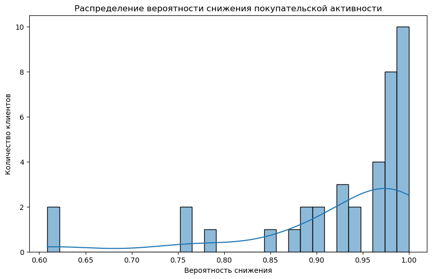

```python
plt.figure(figsize=(10, 6))
sns.histplot(risk_users['вероятность_снижения'], bins=30, kde=True)
plt.title('Распределение вероятности снижения покупательской активности')
plt.xlabel('Вероятность снижения')
plt.ylabel('Количество клиентов')
plt.show()
```

Как можем заметить много людей действительно очень склонны к снижению активности

Корреляционная матрица для числовых переменных

```
The default value of numeric_only in DataFrame.corr is deprecated. In a future version, it will default to False. Select only valid columns or specify the value of numeric_only to silence this warning.
```

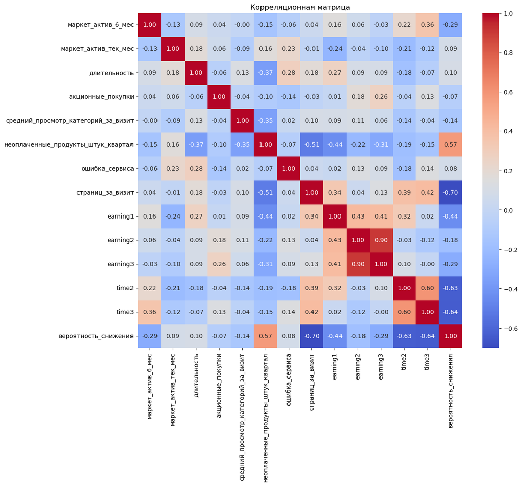

```python
plt.figure(figsize=(12, 10))
sns.heatmap(risk_users.corr(), annot=True, fmt=".2f", cmap="coolwarm")
plt.title('Корреляционная матрица')
plt.show()
```

Анализ акционных покупок

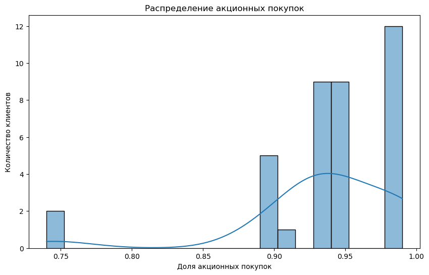

```python
plt.figure(figsize=(10, 6))
sns.histplot(risk_users['акционные_покупки'], bins=20, kde=True)
plt.title('Распределение акционных покупок')
plt.xlabel('Доля акционных покупок')
plt.ylabel('Количество клиентов')
plt.show()
```

Тут можно заметить, что абсолютно большинство людей склонных к снижению активности имеют порядка 90% акционных покупок, это важное замечание!

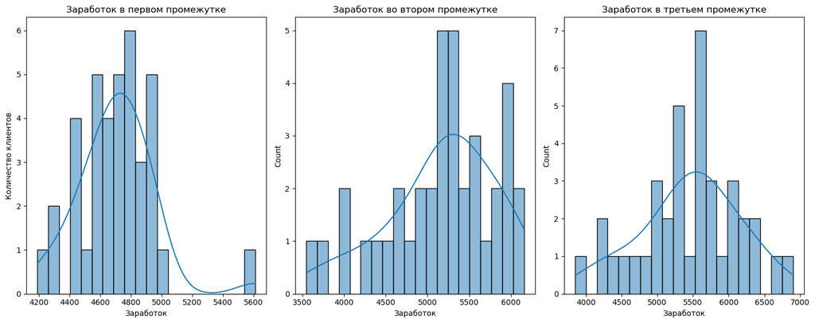

```python
plt.figure(figsize=(15, 6))

plt.subplot(1, 3, 1)
sns.histplot(risk_users['earning1'], bins=20, kde=True)
plt.title('Заработок в первом промежутке')
plt.xlabel('Заработок')
plt.ylabel('Количество клиентов')

plt.subplot(1, 3, 2)
sns.histplot(risk_users['earning2'], bins=20, kde=True)
plt.title('Заработок во втором промежутке')
plt.xlabel('Заработок')

plt.subplot(1, 3, 3)
sns.histplot(risk_users['earning3'], bins=20, kde=True)
plt.title('Заработок в третьем промежутке')
plt.xlabel('Заработок')

plt.tight_layout()
plt.show()
```

Итого: 1) Ориентируясь на популярные категории покупок можно разработать специальные акции, которые будут привлекательны для этой группы клиентов. 2) А значит нужно показывать больше интересующих категорий и товаров для клиентов 3) Поощрение повторных покупок через накопительные бонусы или эксклюзивные предложения для клиентов с высокими тратами 4) Так же не стоит забывать процент акционных покупок и количество неоплаченных товаров. Условно, if товар лежит неоплаченным больше N дней -> показать 'Персональная скидка от продавца дополнительных 10%!'

### 8.3 Сделаем выводы о сегментах

*Мой выбор пал на группу покупателей с максимальной долей покупок по акции и высокой вероятностью снижения покупательской активности. Я пришел к выводу о том, что нужно уделить максимальное внимание акциям и скидкам для этих клиентов, причины на то разные. Я, например, человек живущий не в РФ, поэтому имея несколько маркетплейсов и тщательно слежу за динамикой цен и скидками, потому что по умолчанию цены завышены по сравнению с ценами для клиентов из РФ в виду логистических проблем. Если брать мою идею на счет дополнительных скидок в корзине, я лично на это клевал в своей жизни, это работает и это приятно. (Я.Практикум использует эту схему только в немного другом виде))) )*

## Шаг 9. Общий вывод

**1) Задачей является анализ множества клиентов и данных о них с целью обучения модели МО и подследующим применением её для сегментации клиентов на нужные нам группы под отдельные задачи бизнеса.** **2) Исхродные данные были разделены аж на 4 отдельные таблицы, более того таблицы имели разные форматы представления данных внутри и размеры. Однако, количество уникальных пользователей везде было одинаково. В процессе предобработки мы столкнулись с неудобно названными и структурированными датафреймами, а так же множество неочевидных дубликатов таких, как 'стандартт' и 'стандарт'. Так же порадовало отсутствие явных дубликатов и пропусков.** **3) Для поиска лучшей модели были задействованы пайплайны и автоматизация поиска той самой модели с помощью RandomizedSearchCV. С помощью неё было перебрано 4 разные модели с огромным количеством гиперпараметров внутри, сделать такое руками было бы невероятно долго.** **4) Лучшей моделью стала SVC() с масштабированием MinMaxScaler() и кодировщиком OneHotEncoder()** **5) Таким образом, интересующей нас частью клиентов стали те люди, которые буквально помешаны на акциях (кто же их не любит). Для клиентов, где наблюдается снижение дохода сервиса, полезно проанализировать возможные причины (например, снижение качества обслуживания, изменение предпочтений) и разработать стратегии для их удержания. Так же думаю будет полезен мониторинг изменений в покупательских предпочтениях и быстрая адаптация предложений к текущим трендам.**